# PART I

Enmin Li

2022/4/26

##load packages

```r
library(tidyverse)
library(caret)
```

```r
library(coefplot)
```

##read data set

```r
df_all <- readr::read_csv("final_project_train.csv", col_names = TRUE)
df_all %>% glimpse()
```

```
## Rows: 677
## Columns: 38
## $ rowid    <dbl> 1, 3, 4, 5, 8, 9, 11, 14, 15, 16, 17, 18, 19, 22, 24, 25, 27,~
## $ region   <chr> "XX", "XX", "XX", "XX", "XX", "XX", "XX", "XX", "XX", "XX", "~
## $ customer <chr> "B", "B", "B", "B", "B", "B", "B", "B", "B", "B", "B", "B", "~
## $ xb_01    <dbl> 4.000000, 1.000000, 2.000000, 2.520000, 2.548387, 3.071429, 3~
## $ xb_02    <dbl> 4, 1, 2, 11, 6, 6, 10, 12, 9, 10, 8, 10, 10, 8, 6, 10, 13, 10~
## $ xb_03    <dbl> 4, 1, 2, -6, -1, 1, -4, -4, -2, -4, -2, -2, -2, -4, 1, -4, -3~
## $ xn_01    <dbl> 3.0000000, 2.0000000, 2.0000000, 1.5333333, 0.8387097, 1.8571~
## $ xn_02    <dbl> 3, 2, 4, 9, 3, 8, 6, 10, 10, 4, 6, 8, 9, 5, 7, 12, 12, 6, 6, ~
## $ xn_03    <dbl> 3, 2, 0, -3, -4, -2, -5, -6, -3, -5, -3, -6, -4, -3, 0, -5, -~
## $ xa_01    <dbl> 12.000000, 3.000000, 9.000000, 7.080000, 6.451613, 6.857143, ~
## $ xa_02    <dbl> 12, 3, 9, 29, 17, 18, 24, 27, 20, 19, 15, 24, 24, 15, 14, 26,~
## $ xa_03    <dbl> 12, 3, 9, -7, -2, 2, -9, -5, -3, -3, -1, 1, -2, -3, 3, -4, -5~
## $ xb_04    <dbl> 1.3333333, 1.0000000, 1.0000000, 0.8950476, 1.2247312, 1.1857~
```

[output cut: 25 more lines]

## PART I

1.Visualize the distributions of variables in the data set 1.1Counts for categorical variables

```r
df_all %>% count(outcome)
```

```
## # A tibble: 2 x 2
##   outcome       n
##   <chr>     <int>
## 1 event       127
## 2 non_event   550
```

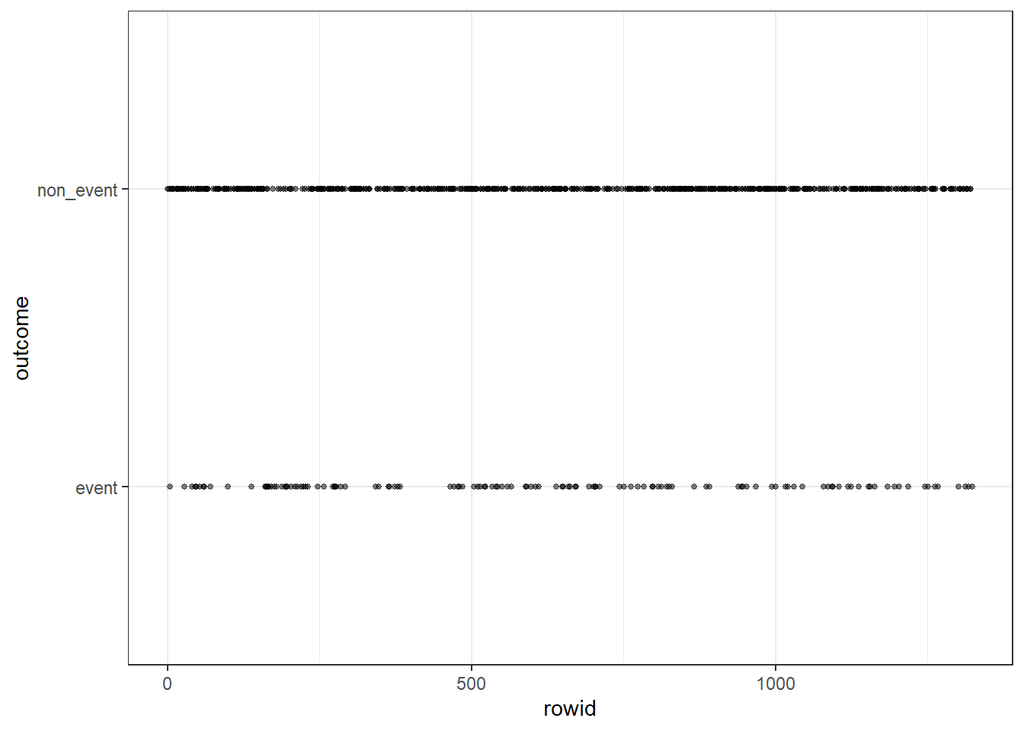

```r
df_all%>%
  ggplot(mapping=aes(x=rowid,y=outcome))+
 geom_point(size = 1, alpha = 0.5)+
  theme_bw()
```

1.2Distributions for continuous variables It doesn’t seem like a normal Gaussian.

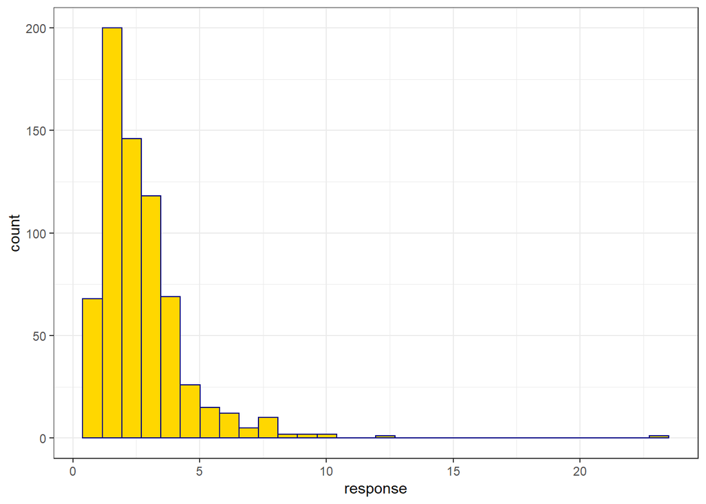

```r
df_all%>%
  ggplot(mapping=aes(x=response))+
  geom_histogram(color = "navyblue", fill = "gold")+
  theme_bw()
```

2.Consider conditioning (grouping or “breaking up”) the continuous variables based on the categorical variables. 2.1Are there differences in continuous variable distributions and continuous variable summary statistics based on region or customer?Yes,I think there are differences.

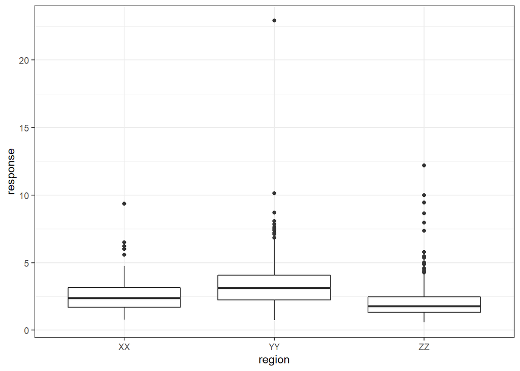

```r
df_all%>%
  ggplot(mapping=aes(x=region,y=response))+
 geom_boxplot()+
  theme_bw()
```

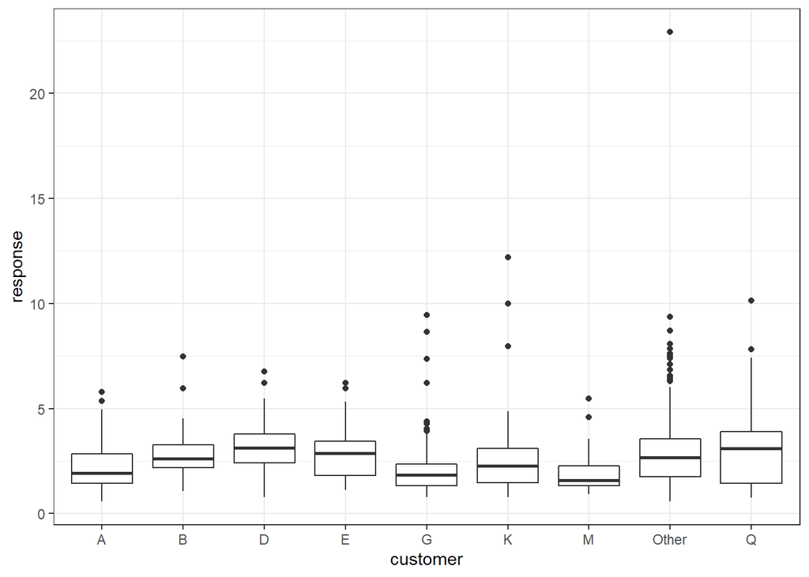

```r
df_all%>%
  ggplot(mapping=aes(x=customer,y=response))+
  geom_boxplot()+
  theme_bw()
```

2.2Are there differences in continuous variable distributions and continuous variable summary statistics based on the binary outcome?

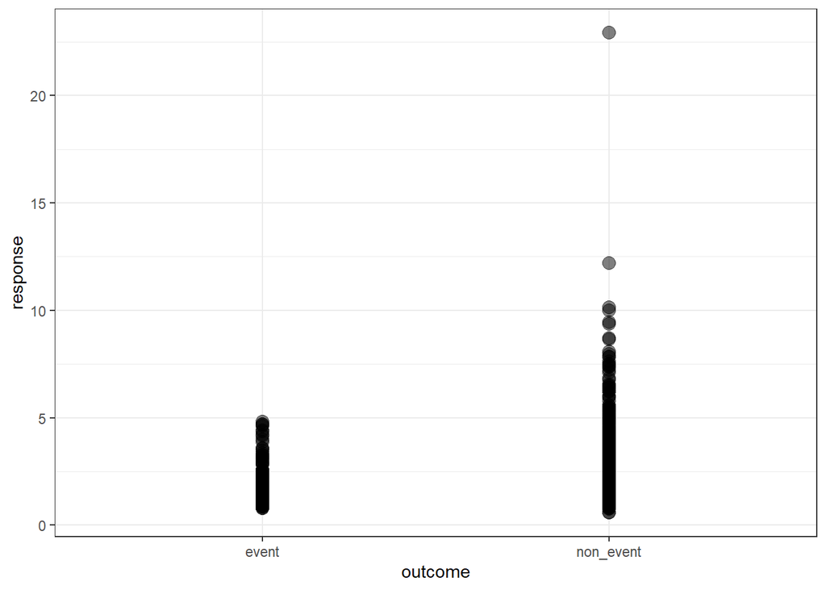

```r
df_all%>%
  ggplot(mapping = aes(x = outcome, y =response)) +
  geom_point(size = 3.5, alpha = 0.5) +
  theme_bw()
```

3. Visualize the relationships between the continuous inputs, are they correlated?

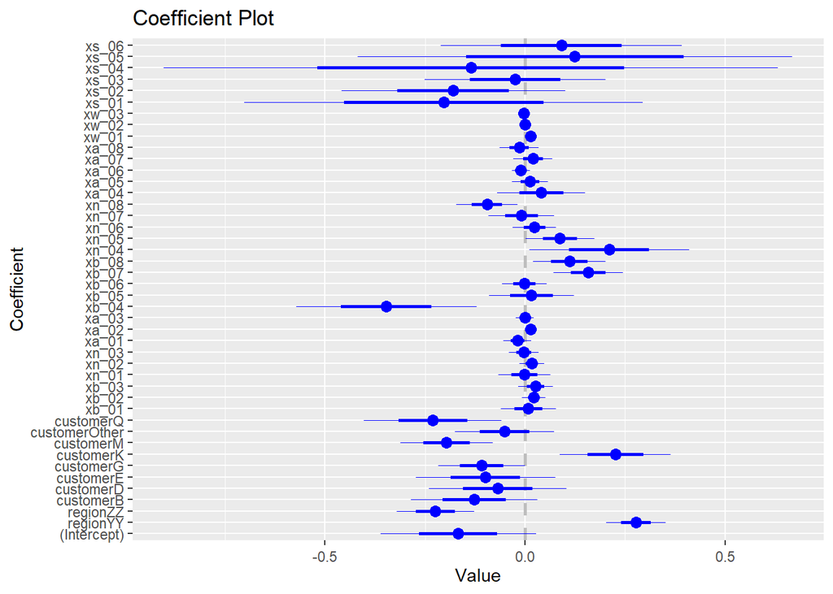

```r
dfii <- df_all %>%
  mutate(y = log(response)) %>%
  select(region, customer, starts_with('x'), y)

mod<-lm(y~.,data=dfii)
coefplot::coefplot(mod)
```

4 Visualize the relationships between the continuous outputs (response and the log-transformed response) with respect to the continuous inputs. • Can you identify any clear trends? Do the trends depend on the categorical inputs?

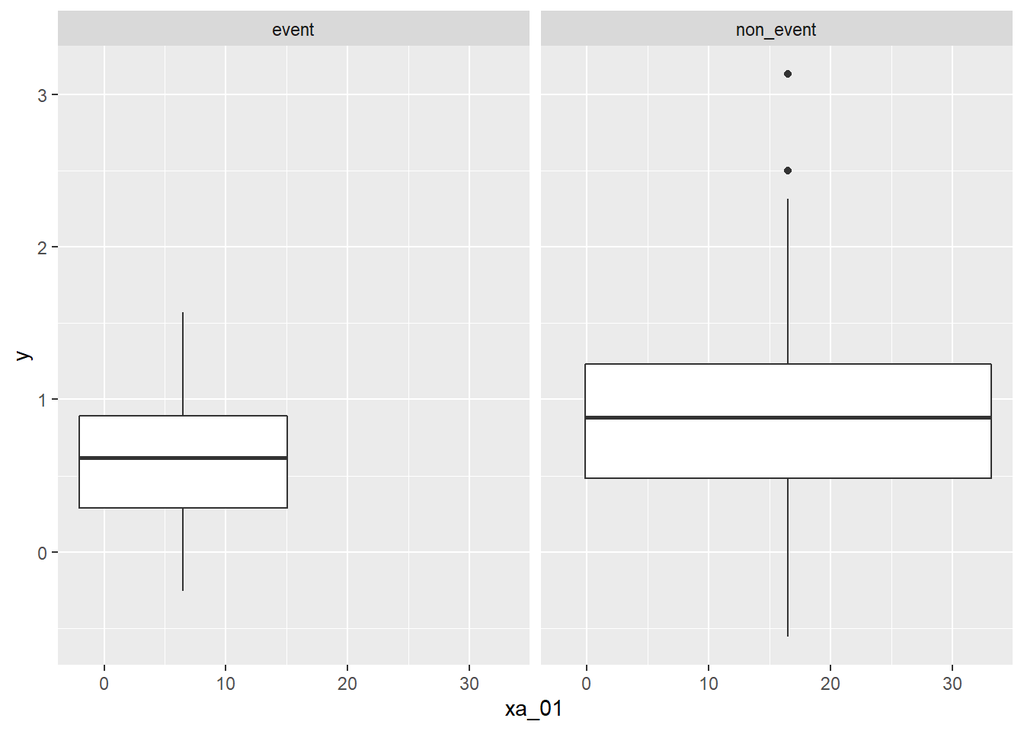

```r
dfii <- df_all %>%
  mutate(y = log(response))

dfii %>%
  ggplot(mapping = aes(x = xa_01, y = y)) +
  geom_boxplot() +
  facet_grid(~outcome)
```

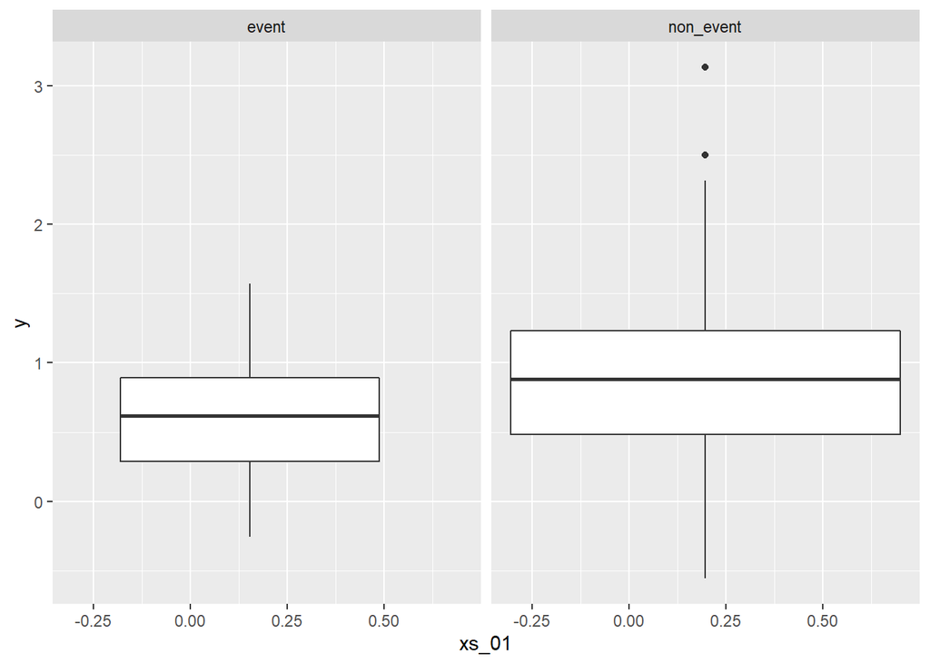

```r
dfii %>%
  ggplot(mapping = aes(x = xs_01, y = y)) +
  geom_boxplot() +
  facet_grid(~outcome)
```

5 How can you visualize the behavior of the binary outcome with respect to the continuous inputs? 5.1 behavior of the binary outcome with respect to xa

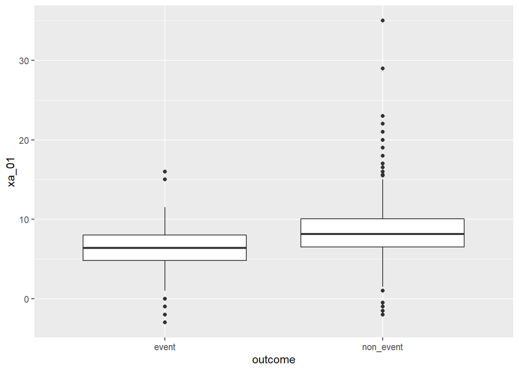

```r
dfii %>%
  ggplot(mapping = aes(x = outcome, y =xa_01)) +
  geom_boxplot()
```

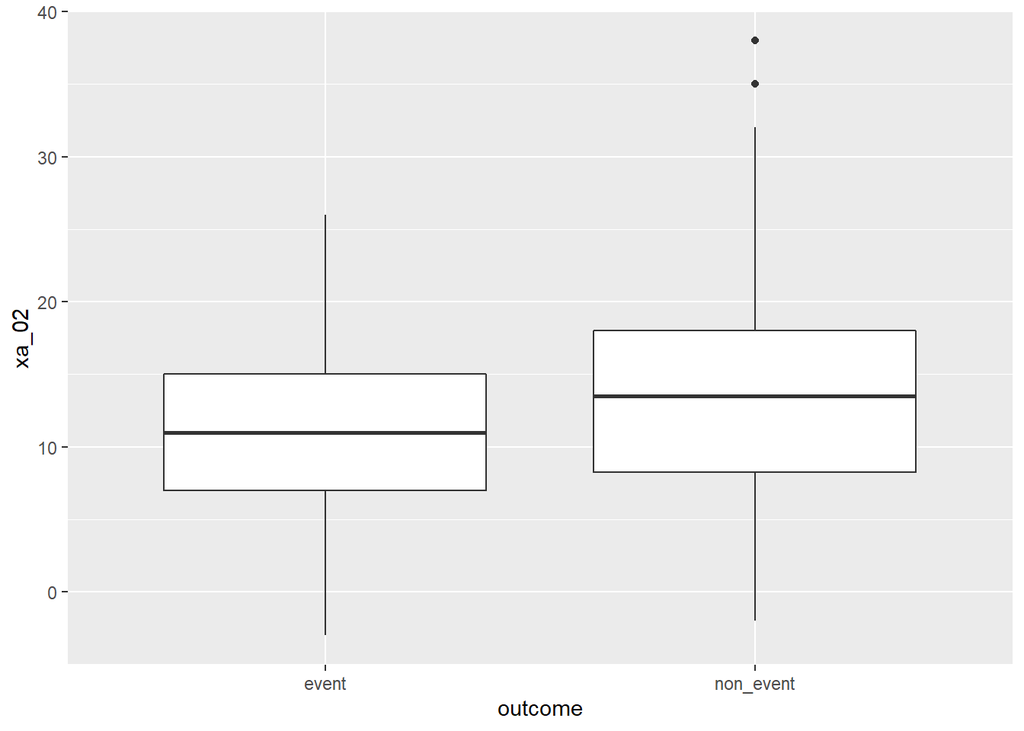

```r
dfii %>%
  ggplot(mapping = aes(x = outcome, y = xa_02)) +
  geom_boxplot()
```

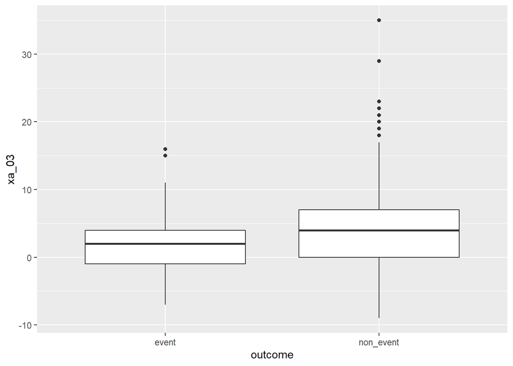

```r
dfii %>%
  ggplot(mapping = aes(x = outcome, y =xa_03)) +
  geom_boxplot()
```

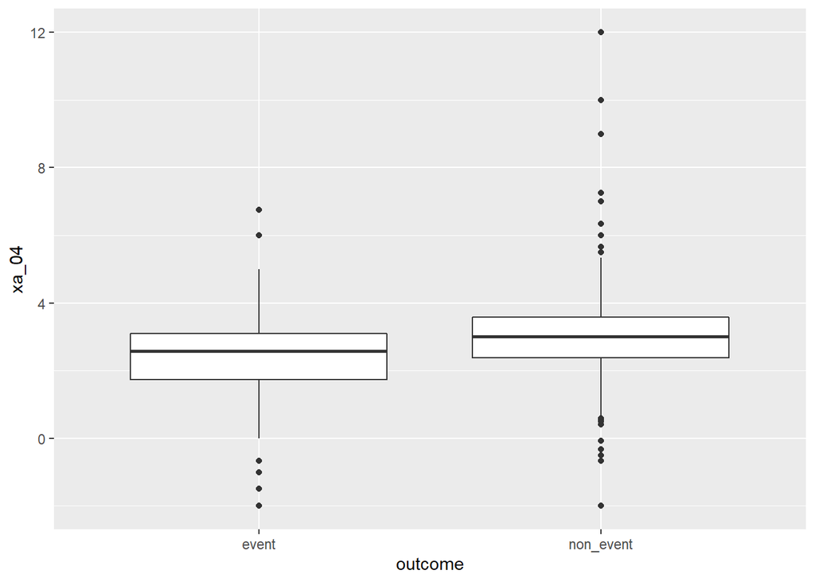

```r
dfii %>%
  ggplot(mapping = aes(x = outcome, y = xa_04)) +
  geom_boxplot()
```

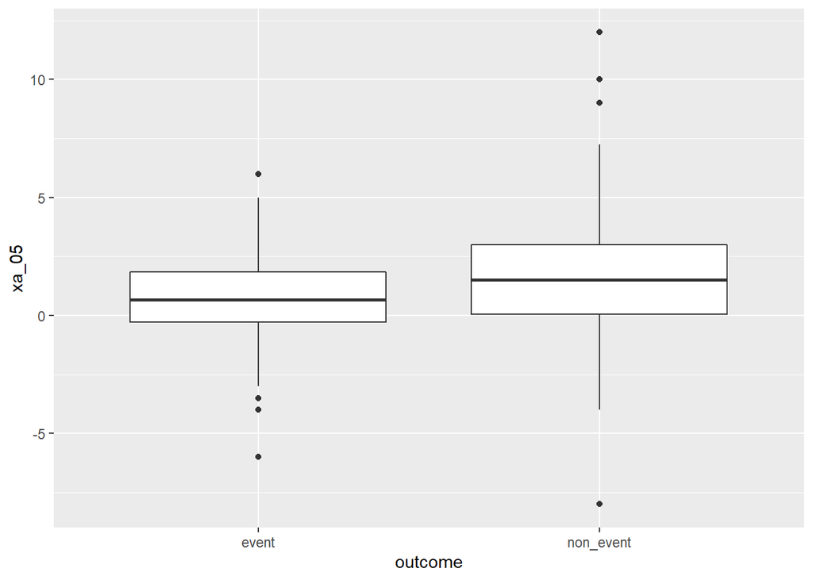

```r
dfii %>%
  ggplot(mapping = aes(x = outcome, y = xa_05)) +
  geom_boxplot()
```

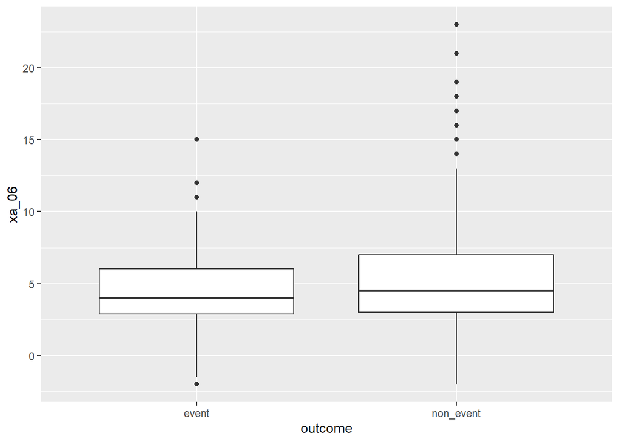

```r
dfii %>%
  ggplot(mapping = aes(x = outcome, y = xa_06)) +
  geom_boxplot()
```

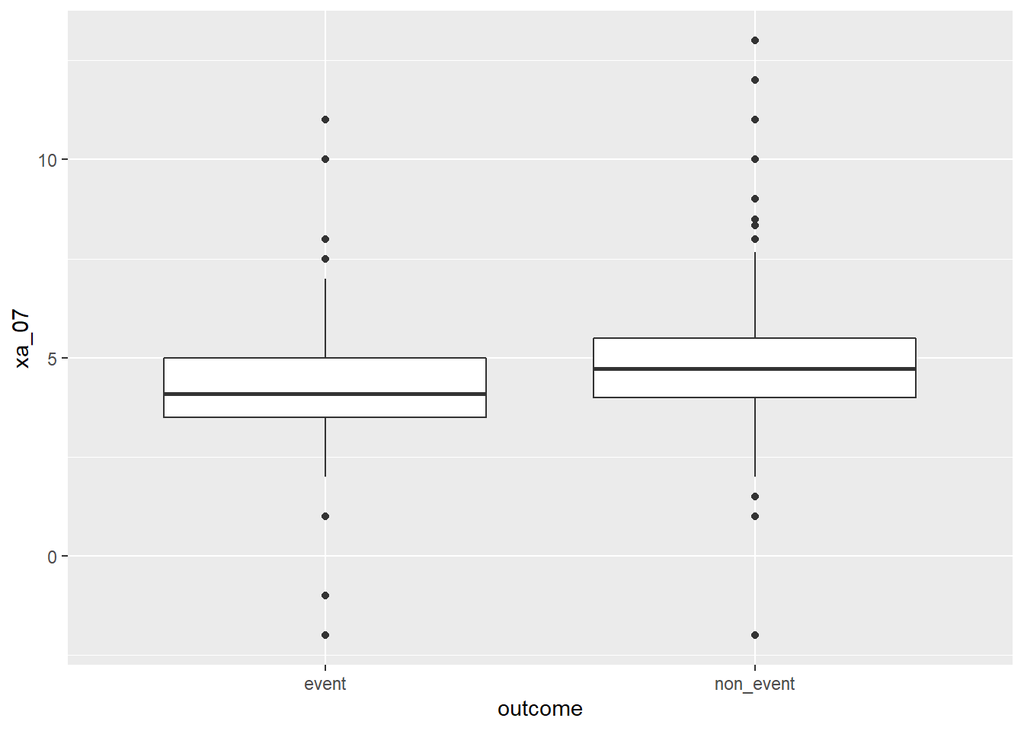

```r
dfii %>%
  ggplot(mapping = aes(x = outcome, y = xa_07)) +
  geom_boxplot()
```

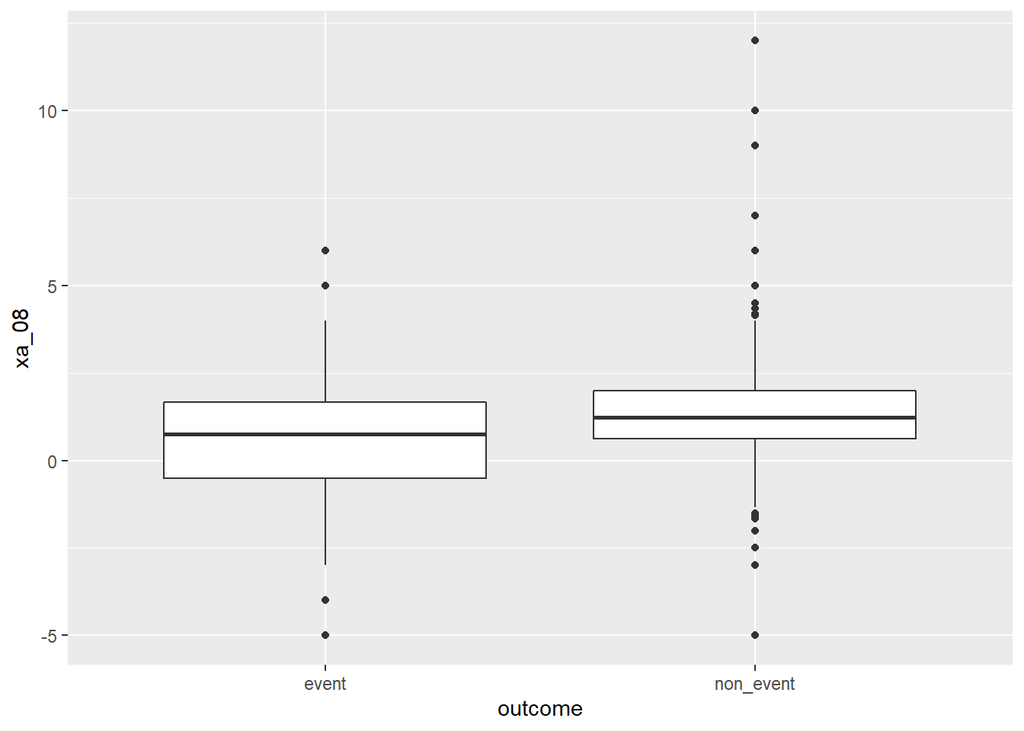

```r
dfii %>%
  ggplot(mapping = aes(x = outcome, y = xa_08)) +
  geom_boxplot()
```

5.2 behavior of the binary outcome with respect to xb

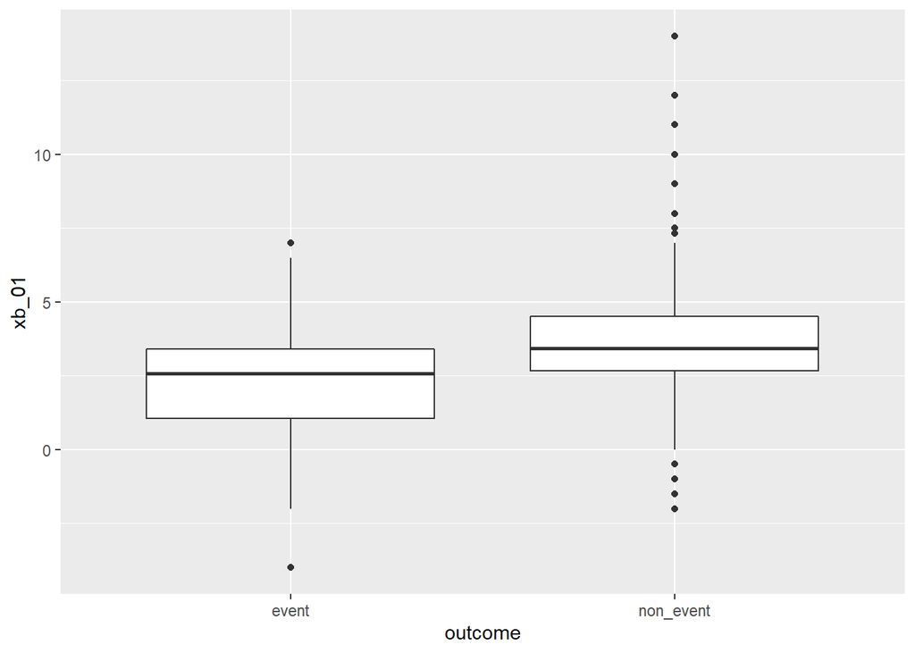

```r
dfii %>%
  ggplot(mapping = aes(x = outcome, y =xb_01)) +
  geom_boxplot()
```

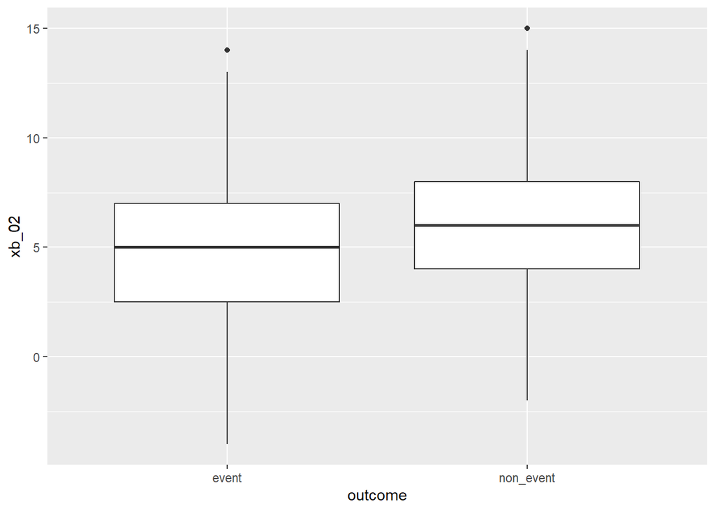

```r
dfii %>%
  ggplot(mapping = aes(x = outcome, y = xb_02)) +
  geom_boxplot()
```

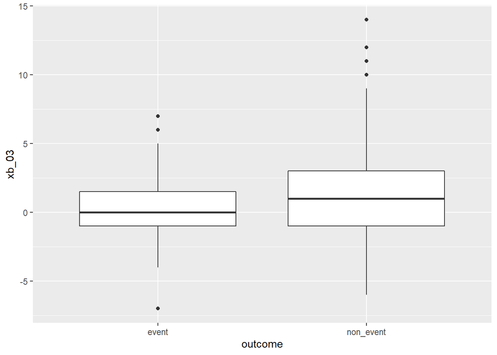

```r
dfii %>%
  ggplot(mapping = aes(x = outcome, y =xb_03)) +
  geom_boxplot()
```

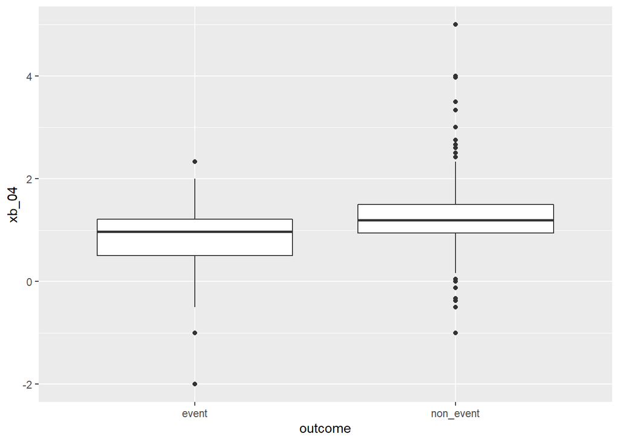

```r
dfii %>%
  ggplot(mapping = aes(x = outcome, y = xb_04)) +
  geom_boxplot()
```

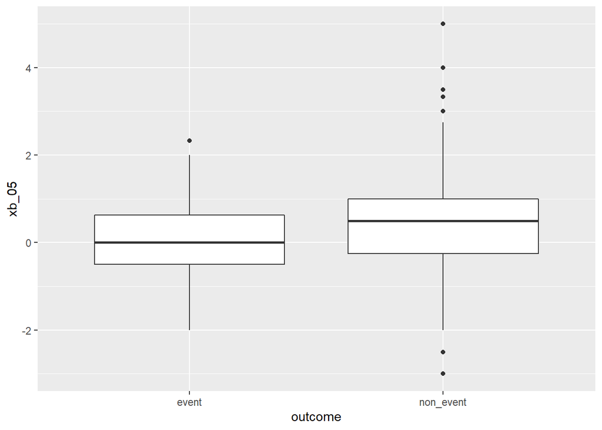

```r
dfii %>%
  ggplot(mapping = aes(x = outcome, y = xb_05)) +
  geom_boxplot()
```

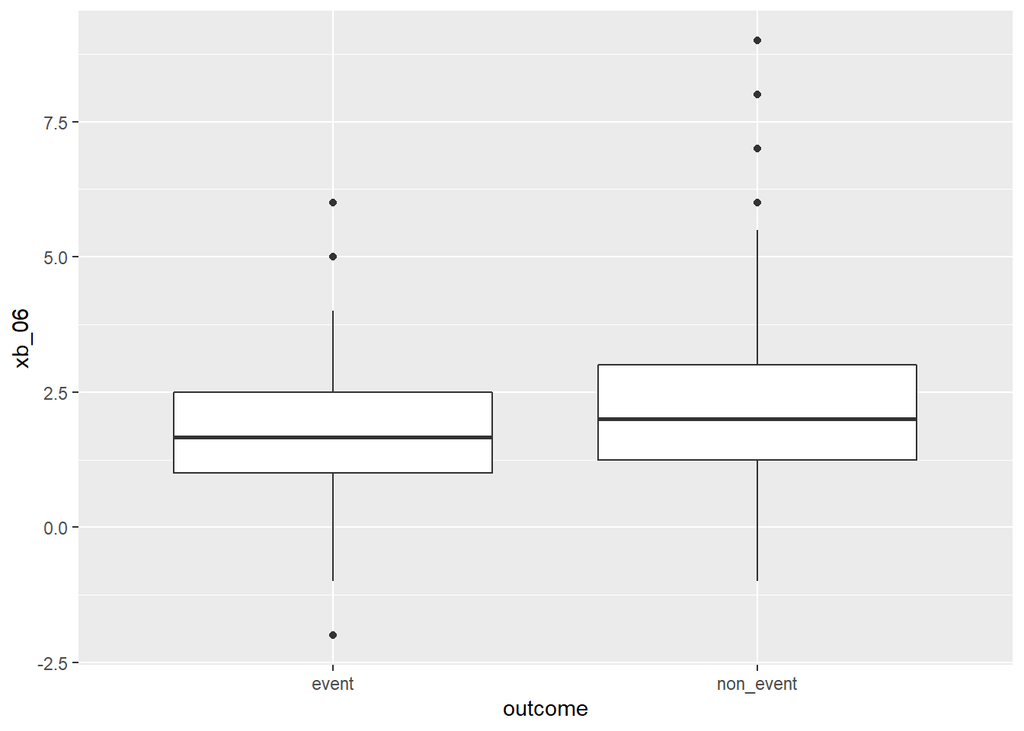

```r
dfii %>%
  ggplot(mapping = aes(x = outcome, y = xb_06)) +
  geom_boxplot()
```

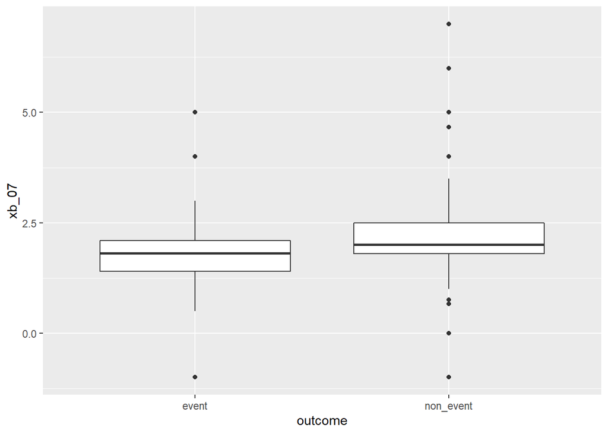

```r
dfii %>%
  ggplot(mapping = aes(x = outcome, y = xb_07)) +
  geom_boxplot()
```

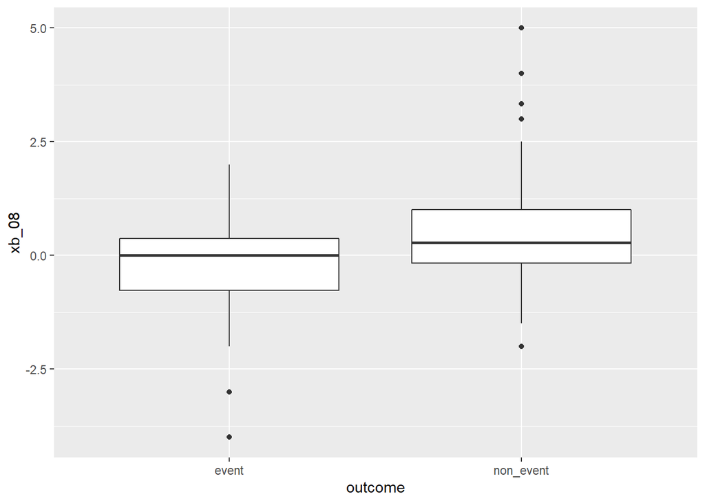

```r
dfii %>%
  ggplot(mapping = aes(x = outcome, y = xb_08)) +
  geom_boxplot()
```

5.3 behavior of the binary outcome with respect to xw

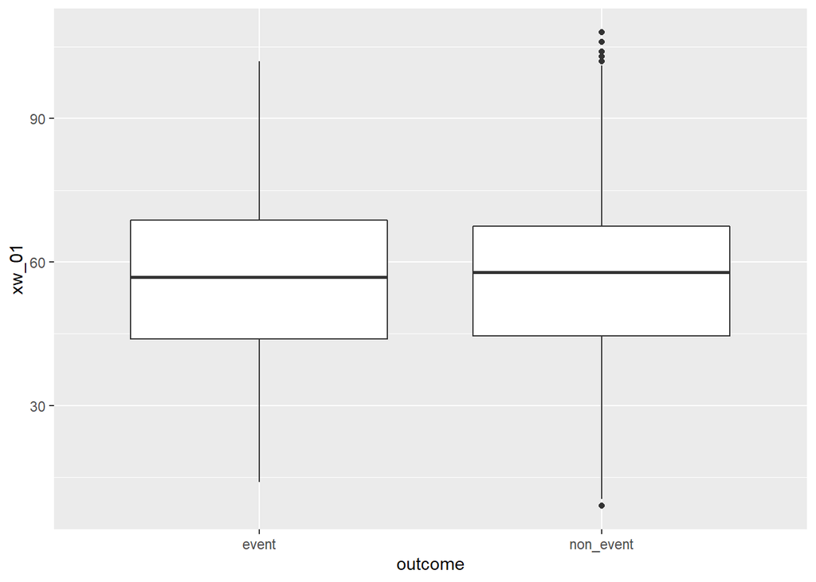

```r
dfii %>%
  ggplot(mapping = aes(x = outcome, y =xw_01)) +
  geom_boxplot()
```

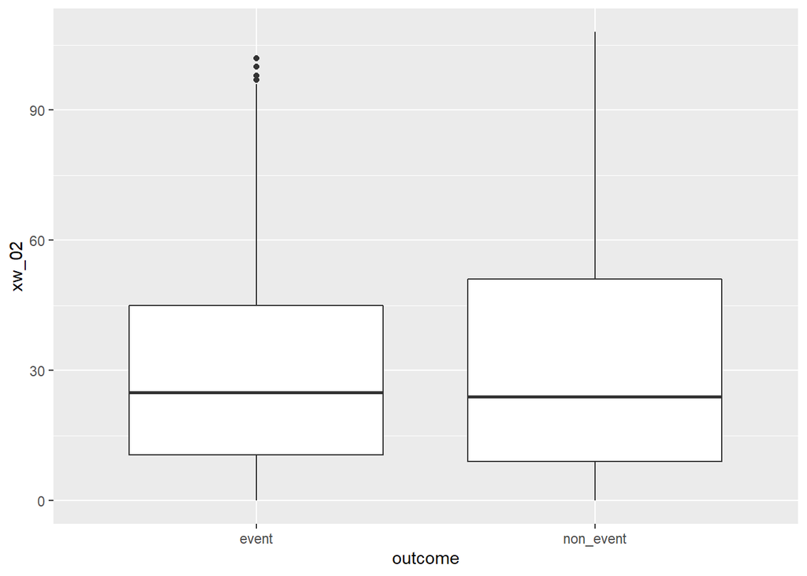

```r
dfii %>%
  ggplot(mapping = aes(x = outcome, y = xw_02)) +
  geom_boxplot()
```

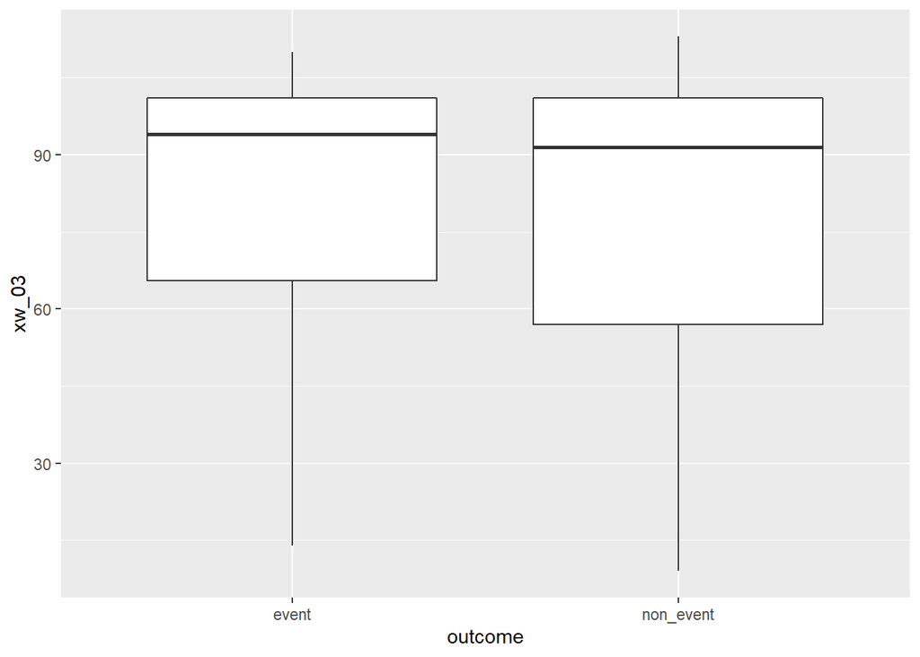

```r
dfii %>%
  ggplot(mapping = aes(x = outcome, y =xw_03)) +
  geom_boxplot()
```

5.4 behavior of the binary outcome with respect to xs

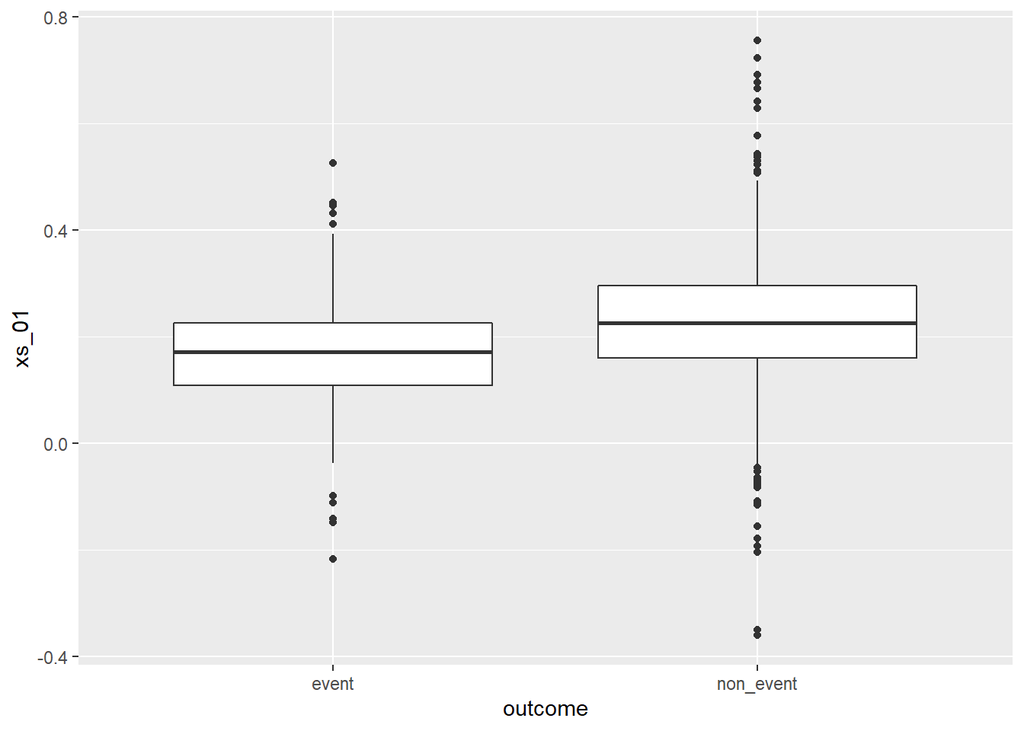

```r
dfii %>%
  ggplot(mapping = aes(x = outcome, y =xs_01)) +
  geom_boxplot()
```

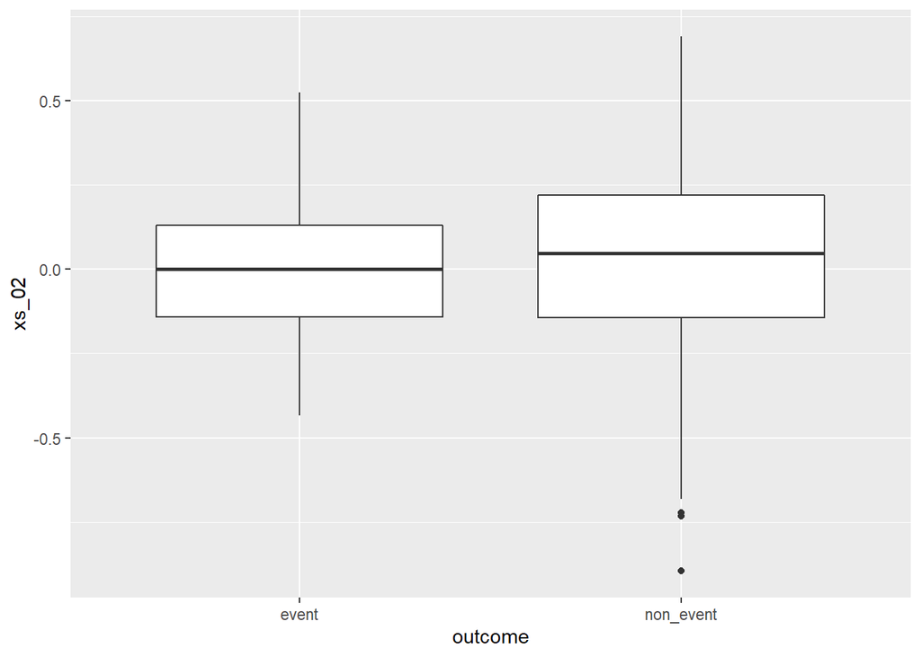

```r
dfii %>%
  ggplot(mapping = aes(x = outcome, y = xs_02)) +
  geom_boxplot()
```

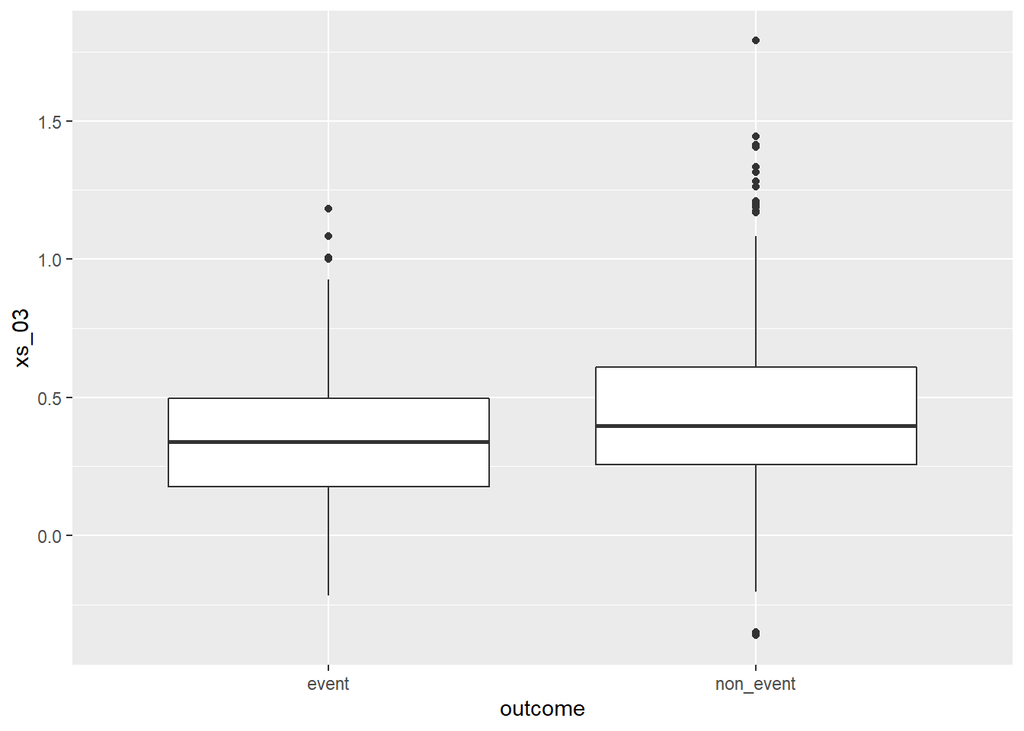

```r
dfii %>%
  ggplot(mapping = aes(x = outcome, y =xs_03)) +
  geom_boxplot()
```